# Project Group 17

## 2.1 Total number of passenger vehicles registered in the Netherlands between 2016 and 2024

Firstly, the total number of passenger cars is presented in relation to the number of EVs.

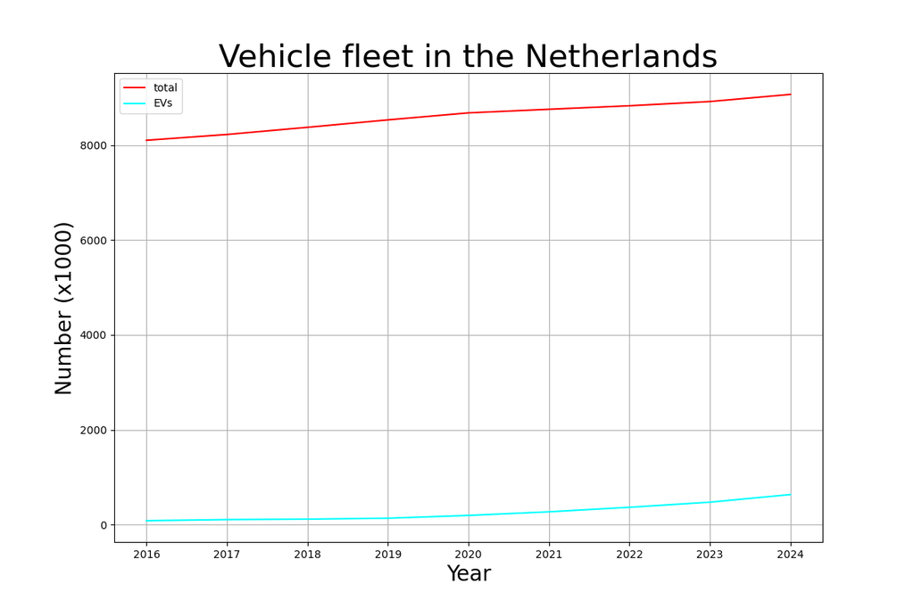

As it is seen from the graph above, EVs accounted for only 1% of the Netherlands' passenger vehicle fleet in 2016, while this percentage rose to 7% in 2024. Currently, it is estimated that 636.700 EVs are in the Dutch roads. Moreover, the gradient of the EV number curve is noticeably higher on and after 2020, where those particular incentives where established.

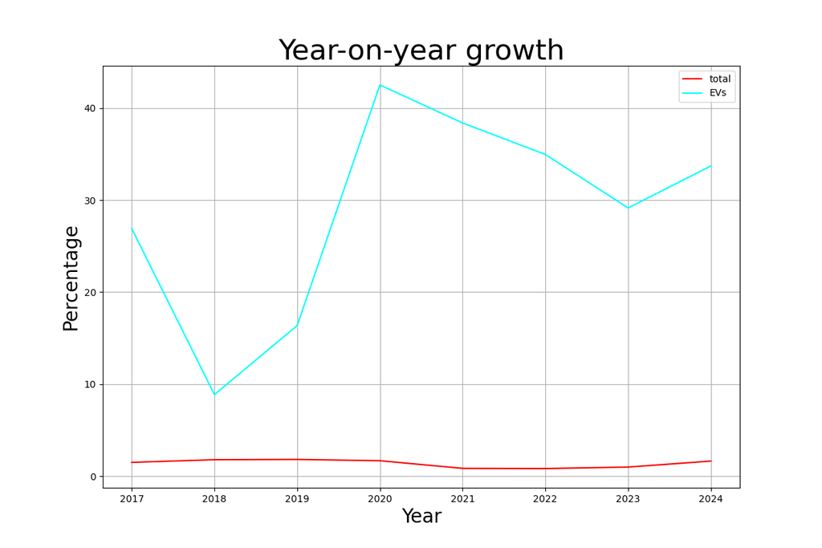

This figure shows the year-on-year growth of the passenger fleet in the Netherlands, in relation with that of the EVs. While the overall growth of the fleet has remained in the same levels over the examined period (0.86% to 1.83%), EVs experienced an increase that fluctuated between 8.87% to 42.5%, with an average value of 28.85%. Also, a spike is observed on the year-on-year growth between 2019 and 2020, while the levels of it have not fallen below 29% until 2024. So, it is safe to say that government subsidies have helped boost electic vehicle sales on a respectable level.

## 2.2 Sale figures of new EVs

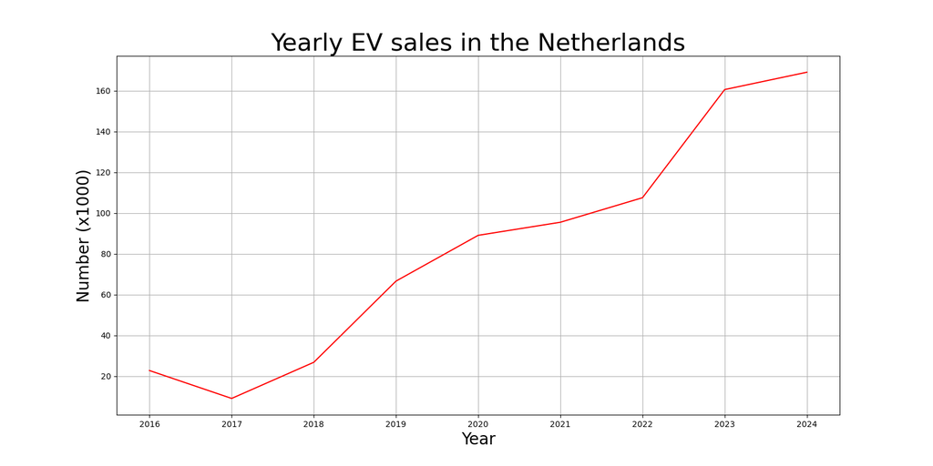

## 2.3 Price of new EVs

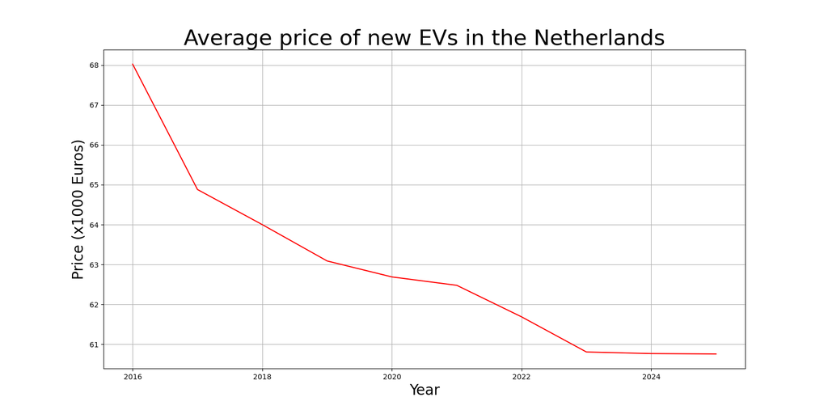

According to this graph, average prices of new EVs were in a steady decline throughout the examined period. Specifically, prices decreased from 68000 Euros in 2016 to about 61000 Euros in 2024. This, combined with the potential 2950 Euro subsidy, creates fairly favourable conditions for new buyers.

As we can see from the analysis above, average prices of new EVs have fallen by almost 11% during the examined period. Meanwhile, an 8-fold increase on electric vehicle sales is observed, while the year-on-year growth of EV sales is significantly larger throughout the 8-year period. This implies that the market share of EVs will take an increasing stake in the vehicle market if this trend continues. A contributing factor to that, are the Dutch government incentives, which undoubtedly help stimulate electric vehicle demand, as it is illustrated by the significant difference between the year-on-year growth of sales between pre and post-incentive period. Nevertheless, during upcoming years, those subsidies will depleat to some extend, so it would be interesting to examine market's behaviour during the upcoming years. This could be a future research material.

# 3. Investment in cycling infrastructure related to the increase in daily cycling use

Investments in cycling infrastructure in the Netherlands have been basic to ensuring that bicycles become a common means of daily transportation. Some of the investments have caused less congestion in traffic, reduced carbon emissions, and promoted healthier lifestyles for the Dutch people. Starting in the 1970s, as a response to the oil crisis and growing concern over road safety, the Dutch government initiated huge investments in cycling infrastructure (BBC News, 2013). This meant constructing thorough networks of separated bike facilities as well as designing traffic-calmed neighborhoods, or "woonerfs." The following decades of established funding expanded these networks, integrated bike routes with public transport, and added amenities such as guarded bike parking and priority-to-cyclists traffic lights. Many trips in ther biggest cities in the Netherlands like Amsterdam and Utrecht are now reported to be taken by bicycle. The sustained commitment to the improvement of cycling infrastructure, supported by national policies and awareness in the public, is demonstrated through a huge increase in the daily use of bicycles within the country. The following graphs show the relation between these investments and increased bicycle traffic in various cities in the Netherlands.

BBC News. (2013, August 7). Why is cycling so popular in the Netherlands? https://www.bbc.com/news/magazine-23587916

# 3.1 Trends in Bicycle Usage by Category in the Netherlands (2015-2022)

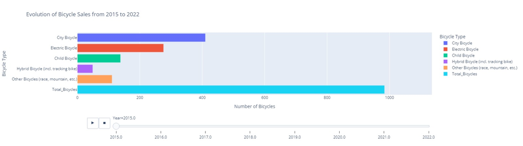

The graph above shows the trend in the number of bicycles sold in the Netherlands from 2015 to 2022 by type. In the graph, sales are divided into the following classes: City Bicycles, Electric Bicycles,Children's Bicycles, Hybrid Bicycles (including tracking bicycles),Other Bicycles (which include racing and mountain bikes) and the number of Total Bicycles sold each year. The graph below is an animated bar chart that represents a yearly comparison. This is to dynamically show how the sales of bicycles have varied over time. In this graph, each category of the bicycle is differentiated by the use of different colors for each type. Therefore, it is very clear which is which. This graph shows horizontal bars that depict a number of bicycles sold for each category. The animation moves from 2015 through 2022, and there are several key trends to identify. As far as Electric Bicycles are concerned, sales have grown remarkably over these years. This can be pinpointed to increased acceptance of electric mobility solutions, advances in technology, rising environmental awareness, and favorable government policies for green transport. As far as City Bicycles go, sales are relatively stable. This signifies that the bicycle remains of primary importance for urban transportation in the Netherlands. This consistency in the sales figures is indicative of the deeply entrenched cycling culture and infrastructure of the country. Thirdly, other bicycle types, such as Hybrid Bicycles, Children's Bicycles, and Other Bicycles (racing and mountain bikes), have minor fluctuations but generally keep steady trends. These may perhaps be attributed to factors that influence consumer preference and recreational trends, which again are determined by the demographic aspect. In general, the Total Bicycles sold annually show the popularity of cycling in the Netherlands. The increased total sales further develop the hypothesis that investment in cycling infrastructure increases bicycle usage for daily transportation. Some striking trends in bicycle sales, from 2015 to 2022, as can be seen in the graph, are a sharp increase in the sale of electric bicycles on one hand and continued popularity regarding city bicycles. These findings give some insight into changing consumer preferences and the results of infrastructure investments in cycling behavior in the Netherlands.

# 3.2 Regional Investment Trends in Infrastructure (2009-2022) and Relative Distribution of Cycle Network Length by Region in 2024

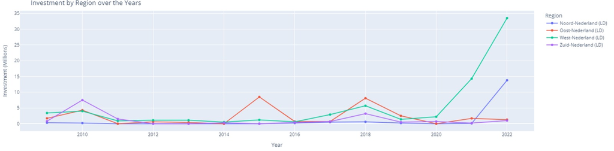

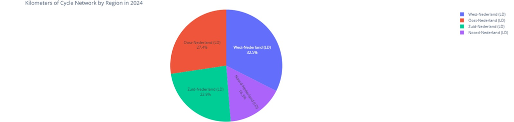

# 3.3 Comparative Analysis of Regional Investments and Average Kilometers Biked per Person (2009-2022)

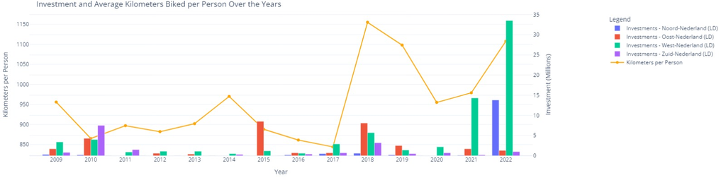

# 3.4 Regional Bicycle Usage Trends per Region

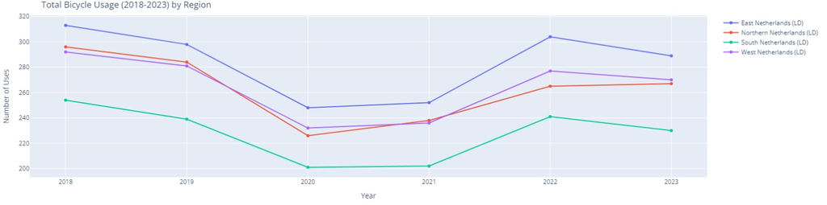

# 3.5 Trends in Bicycle Usage by Travel Motives in the Netherlands (2018-2023)

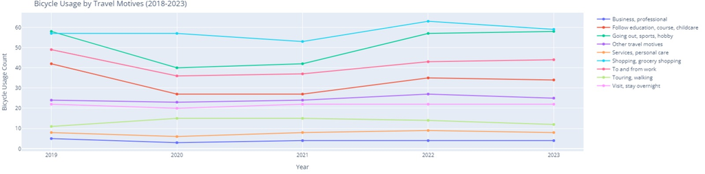